# MLB Payroll analysis

# 7 Distribution of MLB Team Payrolls (Histogram & Density)

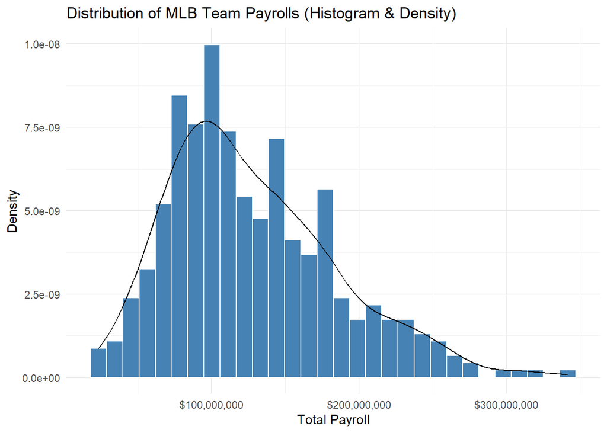

```r
# Raw payroll: histogram on density scale + density curve
ggplot(mlb, aes(x = payroll)) +
  geom_histogram(aes(y = after_stat(density)), bins = 30,
                 fill = "steelblue", color = "white") +
  geom_density(adjust = 1.1) +
  scale_x_continuous(labels = scales::label_dollar()) +
  labs(x = "Total Payroll", y = "Density",
       title = "Distribution of MLB Team Payrolls (Histogram & Density)") +
  theme_minimal()
```

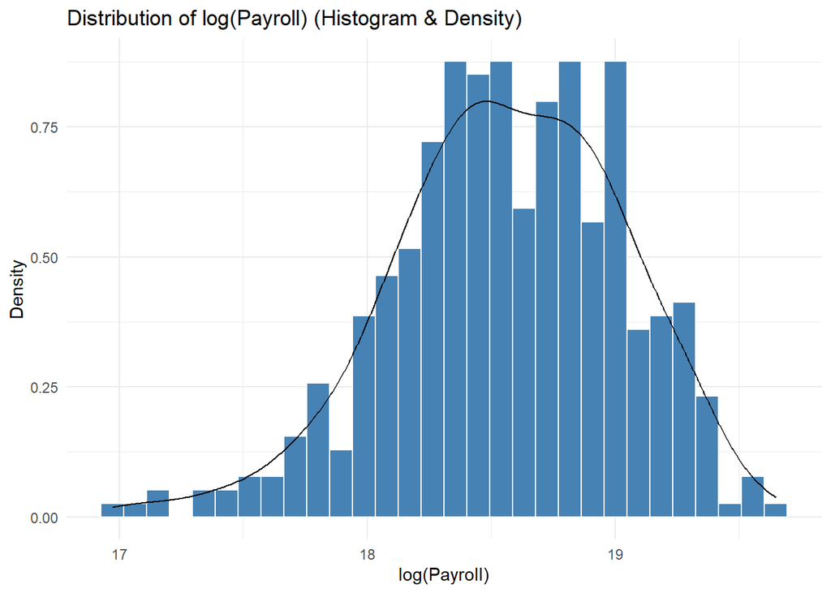

```r
# Log payroll: same idea
ggplot(mlb, aes(x = log_payroll)) +
  geom_histogram(aes(y = after_stat(density)), bins = 30,
                 fill = "steelblue", color = "white") +
  geom_density(adjust = 1.1) +
  labs(x = "log(Payroll)", y = "Density",
       title = "Distribution of log(Payroll) (Histogram & Density)") +
  theme_minimal()
```

For the payroll distribution plots, we can see that: 1.Raw payroll (left) — The histogram with a density overlay is heavily right-skewed: most teams cluster at low–mid payrolls, with a long right tail of a few top spenders. In such skewed data, the mean typically exceeds the median, and outliers can dominate raw-scale comparisons. 2.Using density scale means bar heights reflect probability density (areas integrate to 1), so the histogram and the smooth curve are directly comparable in shape, not in counts. 3.Log payroll (right) — After taking logs, the long tail is compressed, producing a distribution that is more concentrated and closer to bell-shaped. This makes patterns easier to see and supports more stable, interpretable linear/GLM modeling. 4.The contrast between the two panels motivates using log(payroll) in subsequent plots and regressions to reduce skewness and improve comparability across teams (and seasons). MLB payrolls are strongly right-skewed; transforming to log(payroll) yields cleaner visuals and more reliable inference.